# Problem Set Notes (PS 14-17)

Stat 241 – Spring 2017

## PS 14

1. **Avoid ambiguity:** When you use words like “mean” be sure to say what the mean if *of*. We have lots of means in these problems – mean of the response variable, mean of each predictor variable, means of the priors, mean of the posteriors. Some of your answers made it unclear that you knew what mean you were talking about. (And some of your answers made it pretty clear you were talking about the wrong mean.)
2. **Shrinkage:** Shrinkage nudges estimated parameter values in a particular direction. In a simple model, it may be nudged toward the mean of a prior (by concentrating the prior near there). In a multi-level model, you might nudged parameters associated with groups of observations toward a pooled estimate computed using all of the observations. In either case, shrinkage tends to be more pronounced when there is less data (and also when the priors are narrower).
3. **Indexing in models:** For many of you, I was either uncertain you understood the indexing in your multi-levle models or you made it clear that you did not understand. You should always know how many of each “parameter” you have: How many $\alpha_{\mathrm{Group}}$’s are there? (one per group). How many $\sigma_\alpha$’s? (just one).

## PS 15

### 12M1

Some of you missed the point of the exercise. What the author wanted was for you to look at `sigma` across the models and see how it changes.  
What you should notice is that it is smaller for models that include predation as a predictor. This says that this variable helps explain why some tanks have higher survival rates than others. (By way of comparison, size does very little to help – at least not without some additional predictors in the model.)

One way to express this is that `sigma` is measuring *unexplained variation* in survival rates. In principle, if we include in the model everything that determined survival rate, then `sigma` would be 0. Of course, that doesn’t happen in practice. But if we include predictors that help explain the variation in reponse, that reduces the amount of unexplained variation.

Another way to approach this would be to look the distribution of predicted tank survival rates, but to do this you need to take into account the different types of models and the fact that the parameters mean different things in different models. (`link()` would be a good way to go.) You should see that when `sigma` is small, the estimates for individual tanks differ more from each other.

PS. We don’t need to see all of the `depth=2` rows of `precis()` output here. All we really need is the `sigma` row of the output from `coeftab()`.

### 12M2

Adding predation decreases WAIC more than adding size. Looking at the posterior distributions, we see that the posterior distributions for the coefficient on predaction are “farther from zero” (less of the distribution is on the “other side of zero”) than is the case for the coefficients on size.

## PS 16

### 14M3

Biggest differences when moving from model 1 to model 2:

- The second model converges much more slowly (see `n_eff` and `Rhat`), so you may need to do increase `iter` and perhaps do some other tuning to get good results from the second model. I didn’t grade this problem because most of you had trouble getting the model to converge well – which is a pretty important difference!

If you do get things to converge (or interpret the model even though you were nervous about how it was behaving), you will see that

- `bR` changes – the two models pool information from states differently. Because the standard errors associated with the observed data have increased in the second model, the bigger states (which had the small standard errors in model 1) have less influence over our estimates for the smaller states (and can be more influenced by them).
- `sigma` decreases – Basically, we have moved uncertainty around. If we are less sure of the **observed divorce rates**, then we have more flexibility in how we estimate the **estimated divorce rates**, so we can fit more closely to the **estimated data**, reducing `sigma`. (Recall that `sigma` is associated with fitting the **estimated** divorce rate to the observed marriage rate and median age at marriage.)

Side note: There is no reason to print that out of `precis()` with `depth = 2` if it takes up pages of space and you don’t even talk about the second level of the output. (When there are lots of parameters at this level, there are usually better ways to talks about what is going on than to list multiple pages of output without comment.)

### Plots

The plots should have been “self-correcting”, since you could see what you were after. I did a quick look, but didn’t inspect your plots particularly carefully.

If you haven’t already done so, you can see how I created the plots in the [Chapter 14 code](https://rawgit.com/rpruim/Statistical-Rethinking/master/Book-Code/Chapter14-updated.html).

## PS 17

### 10M5

Most of you noticed that using a `logit()` link would force $\lambda$ to be between 0 and 1. Note: This does not require that all the observed counts be between 0 and 1 and does not make $\lambda$ magically a probability. For example, if $\lambda = 1/2$, there is an approximately 9% chance of seeing a count of 2 or greater.

```r
dpois(0:3, lambda = 1/2)
```

```
## [1] 0.60653066 0.30326533 0.07581633 0.01263606
```

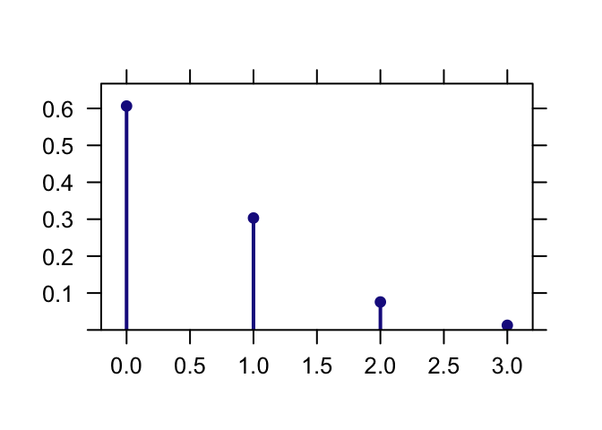

```r
plotDist("pois", lambda = 1/2, xlim = c(-0.2, 3.2))
```

### 10H4

1. When comparing data to fit (retrodicting), it is usually more useful to use `sim()` than to use `link()`. Afterall, `sim()` is there to simulate data according to the model. (But you should probably still use `link()` to get the mean – you will be averaging over less noisy data, so you will get a smoother curve with less sampling.)
2. In this particular case, the results of `sim()` can be a bit “jumpy” because the Poisson distribution is discrete, so things will jump to integer values, and if you counterfactual data uses too fine a grid, you will see some “back and forth” noise between consecutive integers as you transition from one to the next.
3. When adding in forest age, things don’t improve much (although using forest age without percent cover shows that forest age is associated with the amount of salamanders). Most likely, older forests have more cover. If salamanders like cover, then they might like older forests not because they are old but because they have more cover. (That seems more likely than the reverse – that salamanders like old forests and they just happen to have more cover. Also the fit is better using percent cover alone than it is using age alone.)
4. When creating priors, don’t forget about **units**. In this case, forest age and percent cover are rather large values and the number of salamanders is pretty low, so we should expect our coefficients to have pretty small values. (This will be especially pronounced for the interaction term where the two values get multiplited together.) Alternatively, we might like to standardize the variables to give them more moderate size. **Your priors should reflect what you know about the approximate magnitude of the coefficients.**

   Also note that you can increase the digits used in the `precis()` display. This can be necessary if the coefficients are small values. (If you see value and standard error both listed as 0, you probably want more digits.)